# Exploring Cardiovascular Disease Risk Factors Using R

An exploratory analysis of the UCI Cleveland Heart Disease dataset

Author

Idean Zarandi

# Abstract

**Background:** Understanding the relationship between clinical measurements and coronary artery disease (CAD) is important in cardiovascular research. This study explored associations between demographic and clinical characteristics and recorded CAD using a publicly available dataset.

**Methods:** Data from 303 patients in the UCI Cleveland Heart Disease dataset were analysed using R. Descriptive statistics and Welch’s t-tests were used to compare patients with and without recorded obstructive CAD. Multivariable logistic regression investigated associations with age, sex, resting systolic blood pressure and total cholesterol. Exploratory spline modelling and sensitivity analyses were also performed.

**Results:** CAD was recorded in 139 patients (45.9%). Mean systolic blood pressure was higher in patients with CAD (134.57 versus 129.25 mmHg; p = 0.0094). In the initial multivariable model, increasing age (adjusted OR 1.75 per decade, 95% CI 1.29–2.37) and male sex (adjusted OR 5.35, 95% CI 2.93–9.79) were associated with higher odds of CAD. Blood pressure and cholesterol did not demonstrate statistically significant adjusted associations. Exploratory modelling suggested a nonlinear relationship with age.

**Conclusion:** Age and sex were associated with recorded CAD in this historical clinical sample. The findings demonstrate the importance of considering other patient characteristics and evaluating statistical assumptions, although the small, selected population limits their generalisability.

# 1 Background

Coronary artery disease (CAD) is a major cardiovascular condition associated with factors including age, sex, blood pressure and cholesterol (Visseren et al. 2021). Understanding these relationships is important in cardiovascular research and clinical practice.

My background in pharmacy prompted an interest in how clinical measurements can be analysed to better understand disease. This project uses R to investigate associations between age, sex, resting systolic blood pressure, total cholesterol and the presence of CAD in the UCI Cleveland Heart Disease dataset.

The analysis focuses on identifying patterns within the dataset while recognising the limitations of drawing conclusions from a small, historical clinical population.

# 2 Research Objectives

1. Describe the demographic and clinical characteristics of patients in the dataset.
2. Compare cholesterol levels and resting systolic blood pressure between patients with and without recorded CAD.
3. Investigate associations between age, sex, blood pressure, cholesterol and CAD using multivariable logistic regression.
4. Explore potential nonlinear relationships, assess the robustness of the findings and consider the limitations of the analysis.

# 3 Methods

## 3.1 Dataset

Data were obtained from the Cleveland subset of the UCI Heart Disease dataset, originally contributed in 1988. The dataset contains 303 patient records and 14 clinical and demographic variables (Janosi et al. 1988).

The primary outcome was derived from the variable `num`, which describes angiographic coronary artery disease status. A value of 0 indicates less than 50% coronary artery diameter narrowing, while values of 1–4 indicate the presence of greater than 50% narrowing. For this analysis, the outcome was converted into a binary variable representing the absence or presence of angiographically defined obstructive CAD.

The explanatory variables were age (years), recorded sex, resting systolic blood pressure (mmHg) and total serum cholesterol (mg/dL). These were selected based on their clinical relevance to cardiovascular disease.

This was an exploratory, cross-sectional analysis investigating associations with existing CAD rather than predicting future cardiovascular events.

**Data source:** [UCI Machine Learning Repository — Heart Disease](https://doi.org/10.24432/C52P4X).

## 3.2 Data preparation

The original dataset was imported into R, with missing values represented by `?` converted to `NA`. The CAD outcome variable (`num`) was recoded into a binary variable, and recorded sex was converted into a categorical variable with labelled groups.

Data cleaning and preparation were performed using `dplyr`, with the original dataset retained for reference.

## 3.3 Initial data-quality checks

| Records | Missing_Primary | Identical_Raw_Rows |
| --- | --- | --- |
| 303 | 0 | 0 |

## 3.4 Statistical Analysis

All analyses were performed using R, with dplyr for data manipulation and ggplot2 for visualisation (Wickham 2016).

### 3.4.1 Data Preparation and Descriptive Statistics

The dataset was assessed for missing values before analysis. Four observations had missing values for ca and two for thal. However, all variables included in the primary regression model were complete, allowing all 303 patients to be retained.

Patient characteristics were summarised according to CAD status, including the number of patients in each group and their mean age, resting systolic blood pressure and cholesterol levels. Additional descriptive statistics were explored to examine the distribution of clinical measurements.

### 3.4.2 Unadjusted Comparisons

Welch’s two-sample t-tests were used to compare mean resting systolic blood pressure and total cholesterol between patients with and without recorded CAD. This method was chosen because it does not require equal variances between the two groups.

Mean differences were calculated as CAD present minus No CAD, with 95% confidence intervals and two-sided p-values. These comparisons were unadjusted and therefore did not account for differences in other patient characteristics.

### 3.4.3 Multivariable Logistic Regression

Multivariable logistic regression was used to investigate the association between recorded CAD status and four explanatory variables: age, sex, resting systolic blood pressure and total cholesterol.

Age, blood pressure and cholesterol were included as continuous variables, scaled per 10 years, 10 mmHg and 10 mg/dL, respectively. Female sex was used as the reference category.

The initial model assumed a linear relationship between each continuous predictor and the log-odds of CAD. Regression coefficients were converted into adjusted odds ratios (ORs), with 95% Wald confidence intervals calculated to describe the uncertainty around these estimates.

### 3.4.4 Model Checks and Exploratory Nonlinear Modelling

Cook’s distance was used to identify potentially influential observations in the initial logistic regression model. A threshold of 4/n was used as a screening guide. Observations exceeding this threshold were flagged but not automatically excluded from the analysis.

Natural cubic splines with three degrees of freedom were used to explore whether age, systolic blood pressure and cholesterol had nonlinear relationships with the log-odds of CAD. Model fit was compared using likelihood-ratio tests for nested models and the Akaike Information Criterion (AIC).

These analyses were exploratory, and the results were interpreted cautiously because multiple model specifications were examined using the same dataset. The checks did not constitute a complete assessment of model validity.

### 3.4.5 Sensitivity Analysis

A sensitivity analysis was conducted to assess whether the highest recorded cholesterol measurement (564 mg/dL) had a substantial influence on the initial logistic regression results.

The analysis was repeated after excluding this observation, and the adjusted odds ratios were compared with those from the original model.

All 303 patients were retained in the primary analysis. This sensitivity analysis was limited to the original linear-age model and did not assess the robustness of the spline models.

### 3.4.6 Statistical Interpretation

A significance threshold of p < 0.05 was used for exploratory statistical comparisons. Findings were interpreted alongside effect sizes, 95% confidence intervals and their clinical relevance, rather than relying solely on statistical significance.

As multiple statistical comparisons and model specifications were explored, the possibility of chance findings was considered. No adjustment for multiple testing was applied, and the results were not treated as confirmatory evidence.

All findings were interpreted as associations rather than causal relationships. The STROBE statement was consulted as guidance for transparent reporting of observational research (Elm et al. 2007).

# 4 Results

## 4.1 Patient characteristics

Table 1: Descriptive characteristics by CAD status

| cad_group | Patients | Mean_Age | Mean_BP | Mean_Cholesterol |
| --- | --- | --- | --- | --- |
| No CAD | 164 | 52.6 | 129.2 | 242.6 |
| CAD present | 139 | 56.6 | 134.6 | 251.5 |

## 4.2 Age distribution

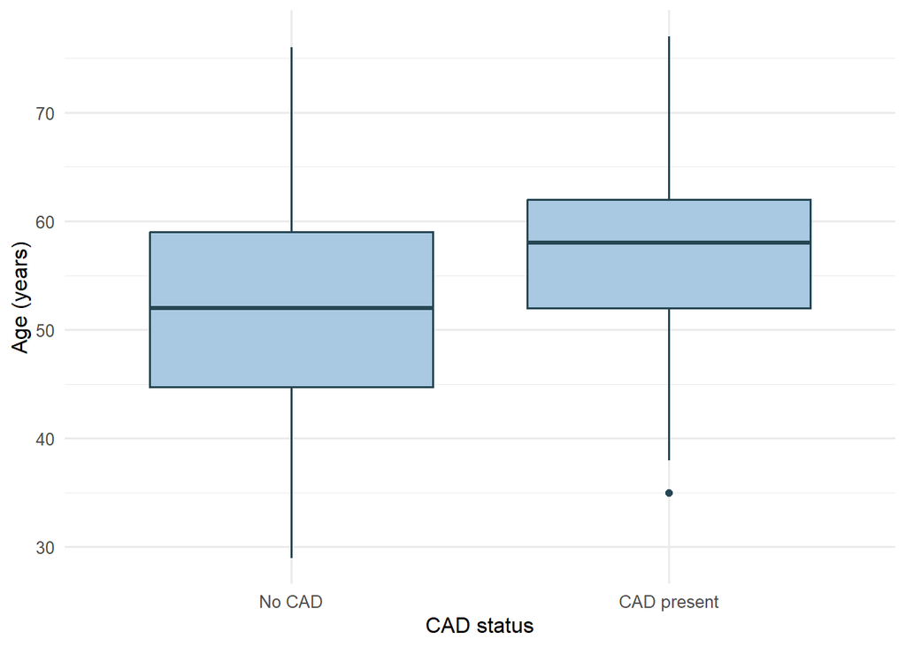

Figure 1: Distribution of patient age by CAD status

## 4.3 Multivariable Logistic Regression

A multivariable logistic regression model was fitted to investigate associations between patient characteristics and the presence of coronary artery disease.

The model included age, sex, resting systolic blood pressure and total cholesterol.

Continuous predictors were scaled to provide odds ratios per 10-unit increase.

Table 2: Adjusted odds ratios for coronary artery disease

| Predictor | Adjusted OR | 95% CI | p-value |
| --- | --- | --- | --- |
| Age (per 10 years) | 1.75 | 1.29 to 2.37 | <0.001 |
| Male vs female | 5.35 | 2.93 to 9.79 | <0.001 |
| Systolic BP (per 10 mmHg) | 1.15 | 0.99 to 1.34 | 0.063 |
| Cholesterol (per 10 mg/dL) | 1.05 | 1.00 to 1.10 | 0.071 |

The model estimates adjusted odds ratios describing associations with existing CAD in this clinical sample, not future cardiovascular risk.

Because exploratory analyses suggested a nonlinear age relationship, the constant per-decade age odds ratio from this linear-age model requires cautious interpretation.

## 4.4 Unadjusted Statistical Comparisons

Welch’s independent-samples t-tests were used to compare mean total cholesterol and resting systolic blood pressure between patients with and without CAD.

These exploratory comparisons were conducted without adjustment for potential confounding variables.

Table 3: Unadjusted comparisons between CAD groups

| Variable | No CAD | CAD present | Difference (95% CI) | p-value |
| --- | --- | --- | --- | --- |
| Cholesterol (mg/dL) | 242.64 | 251.47 | 8.83 (-2.82 to 20.48) | 0.137 |
| Systolic BP (mmHg) | 129.25 | 134.57 | 5.32 (1.31 to 9.32) | 0.009 |

The mean differences and their 95% confidence intervals are expressed as CAD present minus No CAD.

These comparisons are exploratory and should not be interpreted as evidence of causation.

## 4.5 Exploring a Nonlinear Age Association

An exploratory analysis investigated whether allowing age to have a nonlinear association with the log-odds of CAD improved model fit.

A natural cubic spline with three degrees of freedom was compared against the original linear-age regression model.

Table 4: Comparison of linear and nonlinear age models

| Model | AIC |
| --- | --- |
| Linear age | 375.07 |
| Nonlinear age | 370.18 |

The likelihood-ratio test below evaluates whether the additional flexibility improves model fit.

Table 5: Likelihood-ratio test for the age spline

| Resid. Df | Resid. Dev | Df | Deviance | Pr(>Chi) |
| --- | --- | --- | --- | --- |
| 298 | 365.0698 | NA | NA | NA |
| 296 | 356.1843 | 2 | 8.8855 | 0.0118 |

### 4.5.1 Adjusted Age Association

The following figure illustrates the model-estimated probability of existing CAD across ages 40–69, holding blood pressure and cholesterol at their sample medians.

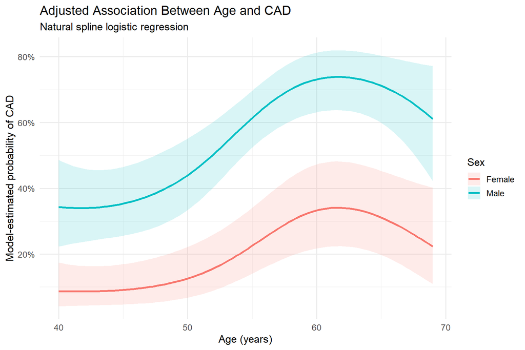

Figure 2: Adjusted model-estimated CAD probability by age and sex (ages 40–69). Shading represents approximate 95% confidence intervals.

These estimates describe existing CAD within a selected clinical sample, rather than future cardiovascular risk.

The plotted age range was restricted to 40–69 years because data were sparse at younger and older ages. The regression model itself used the full dataset.

## 4.6 Sensitivity Analysis and Model Influence

A sensitivity analysis assessed whether the highest recorded cholesterol observation influenced the multivariable logistic regression estimates.

The primary analysis retained all 303 patients. The sensitivity analysis excluded the observation with the maximum cholesterol measurement.

Table 6: Sensitivity analysis excluding the highest cholesterol observation

| Predictor | Original_OR | Sensitivity_OR |
| --- | --- | --- |
| Age (per 10 years) | 1.747 | 1.768 |
| Male vs female | 5.352 | 5.363 |
| Systolic BP (per 10 mmHg) | 1.152 | 1.137 |
| Cholesterol (per 10 mg/dL) | 1.047 | 1.061 |

This sensitivity analysis evaluates the original linear-age reference model. It does not constitute a sensitivity analysis of the age-spline model.

### 4.6.1 Influential Observations

Cook’s distance was used to screen for influential observations in the original regression model.

Table 7: Influence screening summary

| Observations | Screening_Threshold | Flagged_Observations | Maximum_Cooks_Distance |
| --- | --- | --- | --- |
| 303 | 0.0132 | 14 | 0.0723 |

The threshold of 4/n was used as an exploratory screening heuristic. Flagged observations were not automatically excluded from the primary analysis.

# 5 Discussion

## 5.1 Principal Findings

This analysis investigated associations between demographic and clinical characteristics and recorded coronary artery disease (CAD) in 303 patients from the UCI Cleveland Heart Disease dataset.

Patients with recorded CAD were, on average, older and had higher resting systolic blood pressure and total cholesterol than those without recorded obstructive CAD.

The unadjusted analysis found that mean systolic blood pressure was 5.32 mmHg higher in patients with CAD (95% CI 1.31–9.32; p = 0.0094). Although mean cholesterol was also higher in this group, the difference of 8.83 mg/dL (95% CI −2.82 to 20.48; p = 0.137) was not statistically significant.

These comparisons describe differences within this particular clinical sample and do not account for other patient characteristics that may influence the findings.

## 5.2 Multivariable Associations

Multivariable logistic regression was used to investigate associations with CAD while accounting for age, sex, resting systolic blood pressure and total cholesterol.

In the initial model, each additional 10 years of age was associated with approximately 75% higher odds of recorded CAD (adjusted OR 1.75, 95% CI 1.29–2.37). Male patients also had substantially higher estimated odds compared with female patients (adjusted OR 5.35, 95% CI 2.93–9.79).

Resting systolic blood pressure (OR 1.15 per 10 mmHg, p = 0.063) and cholesterol (OR 1.05 per 10 mg/dL, p = 0.071) were not statistically significant after adjustment for the other included variables.

The difference between the unadjusted blood pressure comparison and the adjusted findings highlights the importance of considering other patient characteristics. However, these analyses estimate different statistical quantities, so the change cannot be attributed solely to confounding.

From a clinical perspective, the absence of statistically significant adjusted associations for blood pressure and cholesterol should be interpreted cautiously. Both remain established cardiovascular risk factors, and these findings do not challenge the importance of blood pressure management or lipid-lowering treatment in cardiovascular prevention.

The results are limited to this historical clinical sample and should not be interpreted as causal relationships.

## 5.3 Nonlinear Association With Age

Exploratory modelling suggested a nonlinear relationship between age and the presence of CAD. The natural cubic spline model provided a better fit to the observed data than the initial linear-age model (likelihood-ratio test p = 0.0118; AIC 370.18 versus 375.07).

The fitted relationship suggested that the probability of recorded CAD increased with age before declining beyond approximately 60–65 years. However, there were relatively few patients at the older end of the age distribution, making these estimates less reliable.

This apparent decline should not be interpreted as evidence that older age protects against CAD. The pattern may reflect characteristics of the selected patient population, limited data at older ages or instability in the fitted model.

Although the spline model improved the apparent fit, the analysis was exploratory and the relationship has not been validated using an independent dataset.

## 5.4 Sensitivity Analysis and Model Robustness

Excluding the patient with the highest recorded cholesterol level (564 mg/dL) resulted in relatively small changes to the adjusted odds ratios in the initial logistic regression model. This suggests that the findings were not substantially influenced by this individual observation.

Cook’s distance screening identified 14 observations exceeding the exploratory threshold of 4/n. These observations were retained in the analysis, as a potentially influential observation does not necessarily indicate an incorrect or unreliable patient record.

Although these checks provide some reassurance about the stability of the initial model, they do not establish that the findings are fully robust. Other sources of uncertainty, including model specification, potential confounding and the characteristics of the sample, remain important limitations.

## 5.5 Clinical and Research Implications

The findings demonstrate the importance of interpreting statistical results within their clinical context. Although blood pressure and cholesterol did not show statistically significant adjusted associations with CAD in this dataset, both remain important factors in cardiovascular disease prevention.

From a pharmacy perspective, clinical decisions regarding blood pressure and lipid management should consider the patient’s overall cardiovascular risk, medical history and current treatment rather than individual measurements alone. The findings from this analysis should therefore not be used to guide treatment decisions.

From a research perspective, the project highlights how statistical modelling can help investigate relationships within clinical data, while also demonstrating the limitations of working with a small, historical dataset. Further research using larger, more representative populations and additional clinical variables would be needed to investigate these associations more reliably.

# 6 Limitations

Several limitations should be considered when interpreting the findings of this analysis.

First, the Cleveland Heart Disease dataset contains only 303 patients from a historical, clinically selected population. The sample may not represent the wider population or patients receiving contemporary cardiovascular care, limiting the generalisability of the findings.

Second, the analysis was observational and cross-sectional. It investigated associations with existing CAD rather than the development of cardiovascular disease over time. Therefore, causal conclusions cannot be drawn, and the models cannot estimate an individual’s future cardiovascular risk.

Third, important potential confounding factors, including smoking history, medication use and previous cardiovascular treatment, were not included in the regression model. These factors may influence the observed associations, and their omission limits the interpretation of the adjusted results.

Fourth, although the primary analysis variables had no missing values, other variables in the dataset contained missing observations. The outcome also distinguished patients according to recorded obstructive CAD status rather than providing a complete assessment of coronary health.

Finally, the relatively small sample, particularly at the extremes of the age distribution, may have affected the stability of the nonlinear model. Multiple exploratory analyses were performed without adjustment for multiple testing, increasing the possibility of chance findings. The models were not independently validated, and their estimated probabilities should not be used for clinical decision-making.

# 7 Conclusion

This exploratory analysis of the UCI Cleveland Heart Disease dataset identified associations between age, sex and recorded coronary artery disease (CAD). In the initial multivariable logistic regression model, increasing age and male sex were associated with higher odds of CAD. Although resting systolic blood pressure differed significantly between groups in the unadjusted analysis, neither blood pressure nor cholesterol demonstrated statistically significant adjusted associations.

Exploratory spline modelling suggested that the association between age and CAD may be nonlinear, although uncertainty remained, particularly at older ages. The sensitivity analysis also indicated that the initial regression estimates were not substantially influenced by the highest cholesterol observation.

These findings must be interpreted within the limitations of a small, historical and clinically selected dataset. Further research using larger, more representative populations would be needed to investigate these relationships and assess their generalisability.

# 8 References

Elm, Erik von, Douglas G. Altman, Matthias Egger, Stuart J. Pocock, Peter C. Gøtzsche, and Jan P. Vandenbroucke. 2007. “The Strengthening the Reporting of Observational Studies in Epidemiology (STROBE) Statement: Guidelines for Reporting Observational Studies.” *PLoS Medicine* 4 (10): e296. https://doi.org/10.1371/journal.pmed.0040296.

Janosi, Andras, William Steinbrunn, Matthias Pfisterer, and Robert Detrano. 1988. *Heart Disease*. UCI Machine Learning Repository. https://doi.org/10.24432/C52P4X.

Visseren, Frank L. J., Francois Mach, Yvo M. Smulders, et al. 2021. “2021 ESC Guidelines on Cardiovascular Disease Prevention in Clinical Practice.” *European Heart Journal* 42 (34): 3227–337. https://doi.org/10.1093/eurheartj/ehab484.

Wickham, Hadley. 2016. *Ggplot2: Elegant Graphics for Data Analysis*. Springer-Verlag New York. https://doi.org/10.1007/978-3-319-24277-4.